# Bootstrap & MCMC Tutorial

# Background

## Randomization techniques: why do we use them?

Data resampling and randomization methods are most often used for

1. Evaluating uncertainty levels in data
2. Hypothesis testing
3. Improving model fit/performance

Common methods include

- **Bootstrapping**: “pulling yourself up by your bootstraps”; pulling random samples from your data to *evaluate* the distribution of metrics of interest and obtain *confidence intervals* for computed statistics
- **Permutations**: randomizing your data by keeping some parameters constant and varying others, then comparing to a null distribution to ask if your data structure differs significantly from the null expectation; i.e., *hypothesis testing*
- **Markov Chains**: simulate different possible values of model parameters through random sampling, incorporating fixed and random effects; can *improve model performance* when chains are mixed well. This method is based on Bayesian inference, but for the way we will use it in this tutorial, it basically is just a juiced-up generalized linear mixed effects model (GLMM).

# Tutorial

## Example dataset

The dataset we will use for the tutorial shows feeder visitations by birds in mixed-species flocks in Lincoln, Nebraska. This a summarized version of that dataset which aggregates each individual’s number of morning visitations (sumvisits) and compares them to the lowest temperature from the previous night. If you would like to learn more about the original study, you can find it here: https://academic.oup.com/beheco/article/32/3/407/6163219 and the full dataset and code for its analysis can be found here: https://datadryad.org/stash/dataset/doi:10.5061/dryad.x69p8czgr

The original study used a Markov Chain Monte Carlo model to test the effects of overnight temperature on morning feeder visitation by birds in mixed-species flocks. Here, we will be adding a component not used in the original study to demonstrate bootstrapping. The original study also used permutations to test if pairs of birds with a strong social connection had similar foraging activity. The network permutations will not be covered in this tutorial, but the necessary code can be found through the dryad link above.

We will start the tutorial with bootstrapping then move to Markov Chains.

## Bootstrapping

### Data visualization and exploration

First, we need to load the visitation data and investigate the variables of interest, “sumvisits” (feeder visitation) and “nightlows” (the lowest overnight temperature)

```r
load("morn_visits.dat")

## check out data structure
head(morn_visits)
```

```
##         Date       RFID Species Sex sumvisits  nightlows
## 1 2019-01-27 011016B9B5    WBNU   M        11  -6.722222
## 2 2019-01-29 011016B9B5    WBNU   M         1 -18.888889
## 3 2019-01-30 011016B9B5    WBNU   M        21 -22.222222
## 4 2019-01-31 011016B9B5    WBNU   M        14 -17.777778
## 5 2019-02-01 011016B9B5    WBNU   M        13 -11.722222
## 6 2019-02-02 011016B9B5    WBNU   M         2   1.111111
```

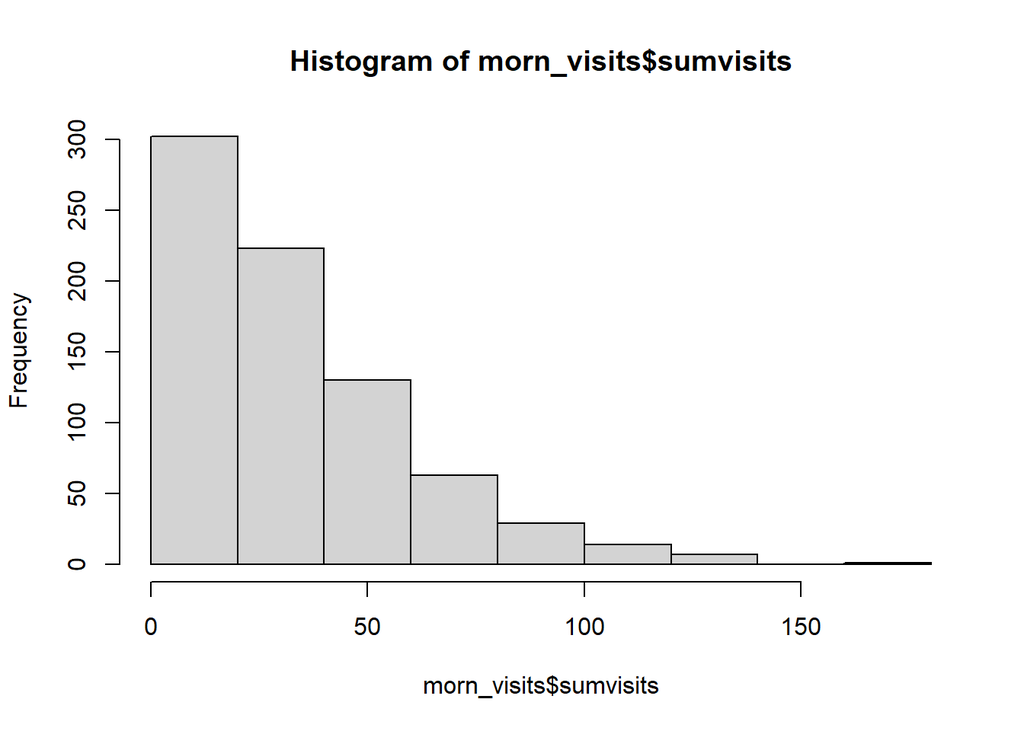

```r
## Let's look at the distributions of our variables of interest
hist(morn_visits$sumvisits) ## left-biased distribution, aka Poisson
```

```r
mean(morn_visits$sumvisits)
```

```
## [1] 33.39792
```

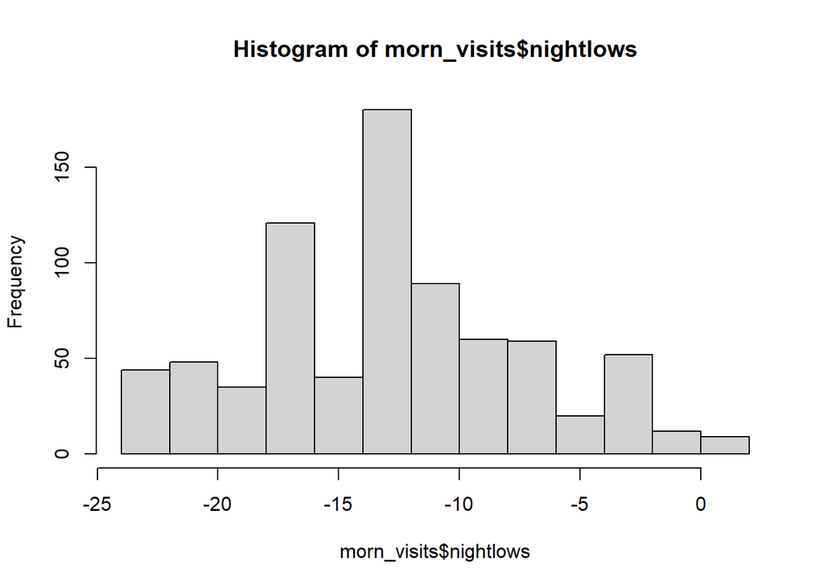

```r
hist(morn_visits$nightlows) ## fairly Gaussian, but not perfect, may need to rescale if model fit is off
```

```r
mean(morn_visits$nightlows)
```

```
## [1] -12.90478
```

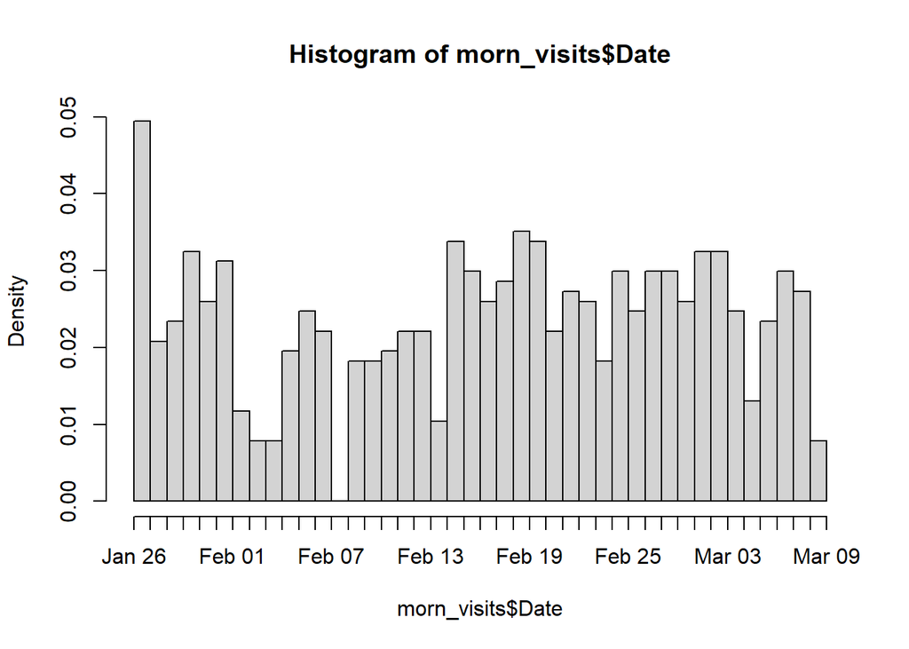

```r
hist(morn_visits$Date, breaks = "day") ## data distribution over the study is fairly even, except for a gap when there were technological issues with the RFID feeders
```

### Simple model

Now that we know our data a little better, let’s start by running a simple generalized linear model to test the effects of overnight temperature on feeder visitation.

```r
glm.1 = glm(formula = sumvisits ~ nightlows, data = morn_visits, family = "poisson")
summary(glm.1)
```

```
##
## Call:
## glm(formula = sumvisits ~ nightlows, family = "poisson", data = morn_visits)
##
## Coefficients:
##             Estimate Std. Error z value Pr(>|z|)
## (Intercept)  3.32029    0.01644  202.01   <2e-16 ***
## nightlows   -0.01434    0.00114  -12.58   <2e-16 ***
## ---
## Signif. codes:  0 '***' 0.001 '**' 0.01 '*' 0.05 '.' 0.1 ' ' 1
##
## (Dispersion parameter for poisson family taken to be 1)
##
##     Null deviance: 16371  on 768  degrees of freedom
## Residual deviance: 16211  on 767  degrees of freedom
## AIC: 20001
##
## Number of Fisher Scoring iterations: 5
```

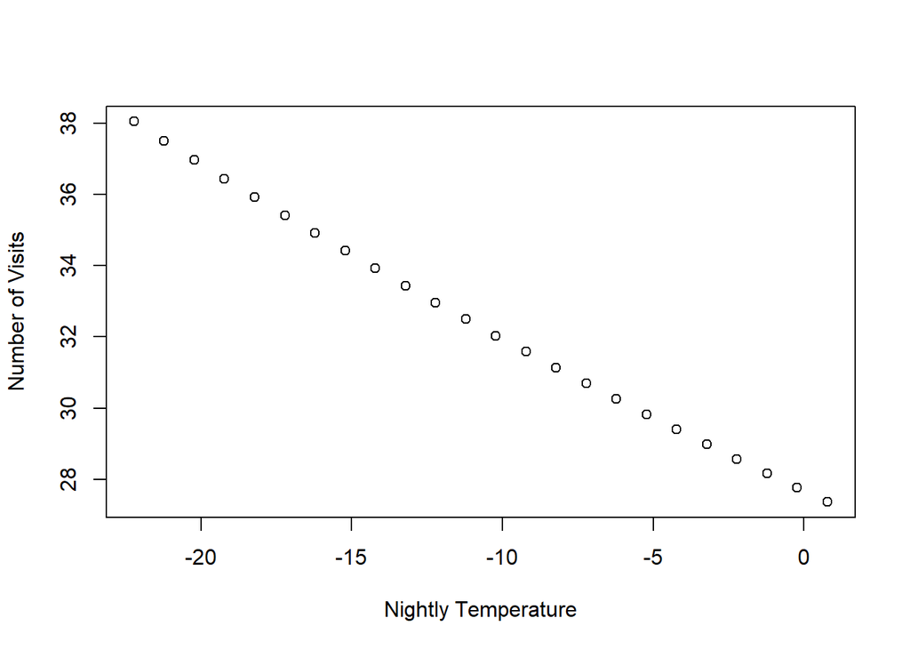

```r
# Predictive graph for Temperature
temp <- data.frame(nightlows = seq(min(morn_visits$nightlows),max(morn_visits$nightlows)), by = 0.5, Date = median(morn_visits$Date), RFID = sample(morn_visits$RFID,1), Species = "DOWO", Sex = "M")
temp$Predict <- predict(glm.1, temp, type = "response") # takes parameters from model and returns values for the response variable
plot(temp$nightlows, temp$Predict, xlab = "Nightly Temperature", ylab = "Number of Visits")
```

Let’s look at the residuals to assess model fit. The fitted vs. residual plot should have no clear trend and there should be a normal distribution of the residuals.

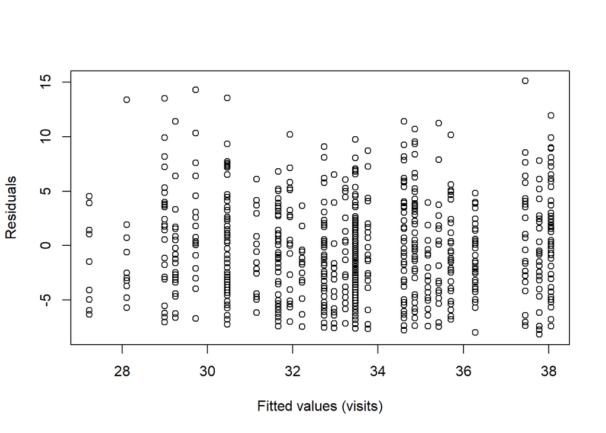

```r
modres = data.frame(x = na.omit(fitted(glm.1)), y = na.omit(resid(glm.1)))
plot(modres$x, modres$y,
     ylab = "Residuals", xlab = "Fitted values (visits)")
```

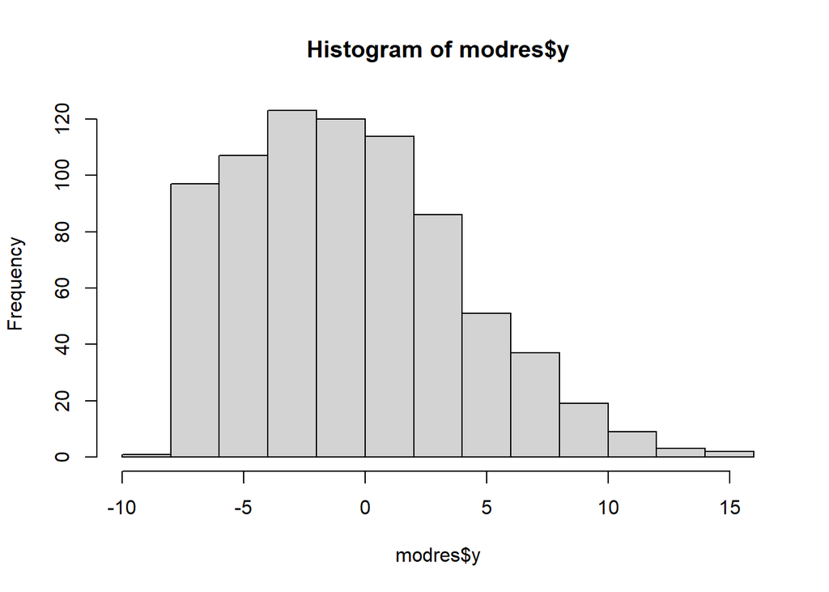

```r
hist(modres$y)
```

Let’s look at the quantiles to assess model fit. The theoretical and sample quantiles should fall along the normal quantiles line.

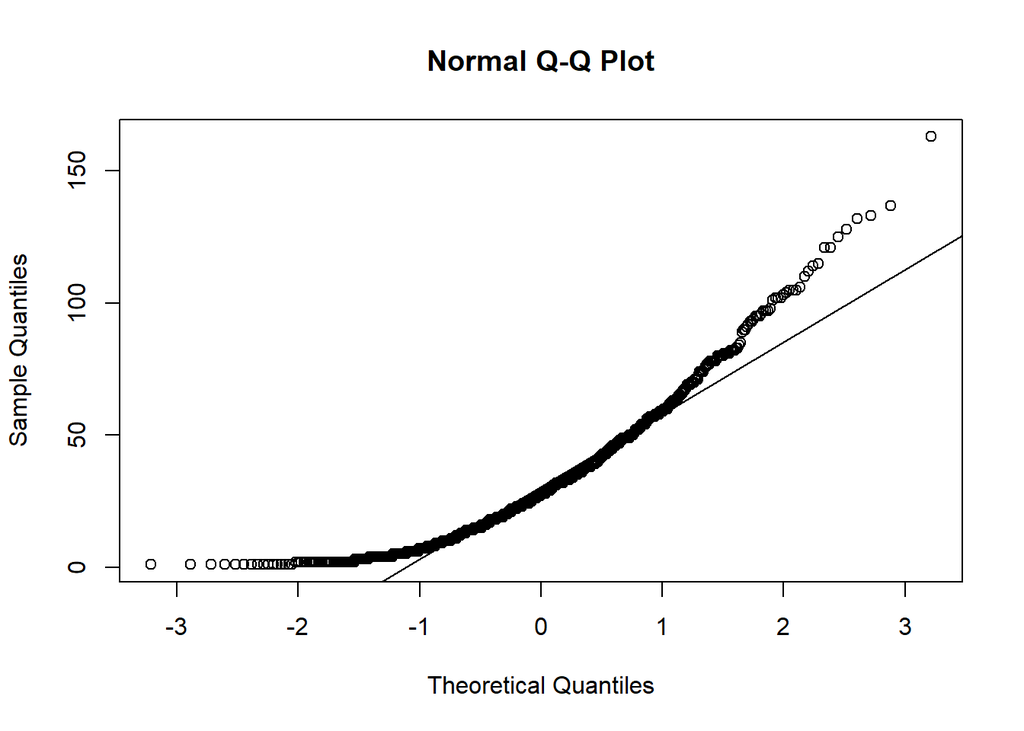

```r
qqnorm(morn_visits$sumvisits)
qqline(morn_visits$sumvisits)
```

Hm, it’s not a perfect model fit. The residuals aren’t quite a normal distribution and our Q-Q plot is not quite a straight line. Maybe the model assumptions aren’t met or the distribution is thrown off by something. Let’s see if we can improve model fit.